# Práctica 2: Limpieza y validación de los datos

Raul Torne Alonso

29 de diciembre de 2017

Dataset: https://www.kaggle.com/kendallgillies/video-game-sales-and-ratings

### 1.Descripción del dataset. ¿Por qué es importante y qué pregunta/problema pretende responder?

El dataset seleccionado contiene información sobre videojuegos. Para obtener dicha información, se han scrapeado las webs vgchartz y metacritic. Esto nos ha permitido conocer datos como el titulo específico del juego, la plataforma, el género al que pertenece, el año de publicación, entre otros. Al mismo tiempo, también se ha podido extraer las puntuaciones aportadas por los usuarios de metacritic, aunque cabe decir que no todos los videojuegos contienen dicha información, pues algunos no han sido valorados.

Ahora bien, el motivo principal por el cual cabe tener presente la gran importancia de este dataset, es que puede ser una herramienta fundamental para las empresas desarrolladoras de videojuegos, pues aporta información sobre las tendencias actuales tanto a nivel de plataformas como en géneros. Pues es necesario tener presente, que en cada época se establecen diferentes modas capaces de influenciar todos los ámbitos, y entre ellos el mundo del ocio y los videojuegos. Así pues, estos datos ayudaran a las empresas reconocidas a mantener su estatus de éxito y a las nuevas a prosperar y evolucionar. Puesto que es imprescindible tener en cuenta, que nos encontramos frente a un mercado cada vez más competitivo debido a el número de nuevas empresas que están surgiendo en este sector. Por lo tanto, es necesario que tengan la posibilidad de realizar un análisis mediante estos datos, para así posteriormente crear contenido adaptado a las preferencias de los usuarios.

En lo que concierne a que pregunta o problema pretende responder, considero que todos estos datos nos pueden responder a varias cuestiones. Por un lado, nos pueden mostrar ¿En qué genero deberían invertir las empresas para garantizar una mayor probabilidad de éxito en Europa? Pues como ya se ha mencionado anteriormente, dichos datos proporcionan información relevante respecto a cuál es el contenido que más éxito está teniendo y por lo tanto en cual han de seguir trabajando. Por otro lado, también puede responder a ¿El género con mayor rating es el que más ventas produce? Es decir, si los productos más vendidos son también los más valorados. Pues de este modo, ayudara a las empresas a deducir si las ventas están o no relacionadas con las puntuaciones y críticas de los usuarios.

```r
videoGamesSales<-read.csv("Video_Game_Sales_as_of_Jan_2017.csv", header=TRUE, sep=",")
videoGamesSales$Year_of_Release<- as.integer(as.character(videoGamesSales$Year_of_Release))
summary(videoGamesSales)
```

```
##                           Name          Platform    Year_of_Release
##  Need for Speed: Most Wanted:   12   DS     :2251   Min.   :1976
##  FIFA 14                    :    9   PS2    :2206   1st Qu.:2003
##  LEGO Marvel Super Heroes   :    9   PS3    :1362   Median :2008
##  Madden NFL 07              :    9   Wii    :1359   Mean   :2007
##  Madden NFL 08              :    9   PSP    :1304   3rd Qu.:2011
##  Ratatouille                :    9   X360   :1298   Max.   :2017
##  (Other)                    :17359   (Other):7636   NA's   :8
##           Genre                             Publisher
##  Action      :3503   Electronic Arts             : 1380
##  Sports      :2408   Activision                  : 1005
##  Misc        :1813   Namco Bandai Games          :  972
##  Role-Playing:1545   Ubisoft                     :  970
##  Adventure   :1478   Konami Digital Entertainment:  865
##  Shooter     :1349   THQ                         :  728
##  (Other)     :5320   (Other)                     :11496
##     NA_Sales          EU_Sales          JP_Sales         Other_Sales
##  Min.   : 0.0000   Min.   : 0.0000   Min.   : 0.00000   Min.   : 0.00000
##  1st Qu.: 0.0000   1st Qu.: 0.0000   1st Qu.: 0.00000   1st Qu.: 0.00000
##  Median : 0.0700   Median : 0.0200   Median : 0.00000   Median : 0.01000
##  Mean   : 0.2545   Mean   : 0.1407   Mean   : 0.07502   Mean   : 0.04591
##  3rd Qu.: 0.2300   3rd Qu.: 0.1000   3rd Qu.: 0.03000   3rd Qu.: 0.03000
##  Max.   :41.3600   Max.   :28.9600   Max.   :10.22000   Max.   :10.57000
##
##   Global_Sales      Critic_Score    Critic_Count      User_Score
##  Min.   : 0.0100   Min.   :13.00   Min.   :  3.00   Min.   :0.000
##  1st Qu.: 0.0500   1st Qu.:60.00   1st Qu.: 11.00   1st Qu.:6.400
##  Median : 0.1600   Median :71.00   Median : 21.00   Median :7.500
##  Mean   : 0.5165   Mean   :68.91   Mean   : 26.19   Mean   :7.117
##  3rd Qu.: 0.4500   3rd Qu.:79.00   3rd Qu.: 36.00   3rd Qu.:8.200
##  Max.   :82.5400   Max.   :98.00   Max.   :113.00   Max.   :9.700
##                    NA's   :9080    NA's   :9080     NA's   :9618
##    User_Count          Rating
##  Min.   :    4.0          :7164
##  1st Qu.:   10.0   E      :4120
##  Median :   25.0   T      :3045
##  Mean   :  162.7   M      :1599
##  3rd Qu.:   81.0   E10+   :1473
##  Max.   :10766.0   EC     :   8
##  NA's   :9618      (Other):   7
```

### 2. Limpieza de los datos.

#### 2.1 Selección de los datos de interés a analizar. ¿Cuáles son los campos más relevantes para responder al problema?

Los campos más relevantes son “Genre”, “Year_of_Release”, “**_Sales“,”*_score"

#### 2.2 ¿Los datos contienen ceros o elementos vacíos? ¿Y valores extremos? ¿Cómo gestionarías cada uno de estos casos?

Los datos que contienen los scores contienen elementos vacios. Por ello mediante la distancia de Gower predecimos las puntuaciones por similitud de videojuegos permitiendo utilizar todos los datos para nuestra predicción.

```r
require(VIM)
videoGamesSales <- kNN(videoGamesSales, k = 6)
```

[output not shown]

```r
summary(videoGamesSales)
```

```
##                           Name          Platform    Year_of_Release
##  Need for Speed: Most Wanted:   12   DS     :2251   Min.   :1976
##  FIFA 14                    :    9   PS2    :2206   1st Qu.:2003
##  LEGO Marvel Super Heroes   :    9   PS3    :1362   Median :2008
##  Madden NFL 07              :    9   Wii    :1359   Mean   :2007
##  Madden NFL 08              :    9   PSP    :1304   3rd Qu.:2011
##  Ratatouille                :    9   X360   :1298   Max.   :2017
##  (Other)                    :17359   (Other):7636
##           Genre                             Publisher
##  Action      :3503   Electronic Arts             : 1380
##  Sports      :2408   Activision                  : 1005
##  Misc        :1813   Namco Bandai Games          :  972
##  Role-Playing:1545   Ubisoft                     :  970
##  Adventure   :1478   Konami Digital Entertainment:  865
##  Shooter     :1349   THQ                         :  728
##  (Other)     :5320   (Other)                     :11496
##     NA_Sales          EU_Sales          JP_Sales         Other_Sales
##  Min.   : 0.0000   Min.   : 0.0000   Min.   : 0.00000   Min.   : 0.00000
##  1st Qu.: 0.0000   1st Qu.: 0.0000   1st Qu.: 0.00000   1st Qu.: 0.00000
##  Median : 0.0700   Median : 0.0200   Median : 0.00000   Median : 0.01000
##  Mean   : 0.2545   Mean   : 0.1407   Mean   : 0.07502   Mean   : 0.04591
##  3rd Qu.: 0.2300   3rd Qu.: 0.1000   3rd Qu.: 0.03000   3rd Qu.: 0.03000
##  Max.   :41.3600   Max.   :28.9600   Max.   :10.22000   Max.   :10.57000
##
##   Global_Sales      Critic_Score    Critic_Count      User_Score
##  Min.   : 0.0100   Min.   :13.00   Min.   :  3.00   Min.   :0.000
##  1st Qu.: 0.0500   1st Qu.:59.00   1st Qu.:  8.00   1st Qu.:6.600
##  Median : 0.1600   Median :65.00   Median : 11.00   Median :7.400
##  Mean   : 0.5165   Mean   :65.88   Mean   : 17.88   Mean   :7.178
##  3rd Qu.: 0.4500   3rd Qu.:72.00   3rd Qu.: 22.00   3rd Qu.:7.900
##  Max.   :82.5400   Max.   :98.00   Max.   :113.00   Max.   :9.700
##
##    User_Count           Rating      Name_imp       Platform_imp
##  Min.   :    4.00          :7164   Mode :logical   Mode :logical
##  1st Qu.:    8.00   E      :4120   FALSE:17416     FALSE:17416
##  Median :   15.00   T      :3045   NA's :0         NA's :0
##  Mean   :   83.14   M      :1599
##  3rd Qu.:   33.00   E10+   :1473
##  Max.   :10766.00   EC     :   8
##                     (Other):   7
```

[output cut: 17 more lines]

```
##  Mode :logical    Mode :logical    Mode :logical   Mode :logical
##  FALSE:8336       FALSE:8336       FALSE:7798      FALSE:7798
##  TRUE :9080       TRUE :9080       TRUE :9618      TRUE :9618
##  NA's :0          NA's :0          NA's :0         NA's :0
##
##
##
##  Rating_imp
##  Mode :logical
##  FALSE:17416
##  NA's :0
##
##
##
##
```

También tenemos valores extremos en las ventas, ya que siempre hay algún juego que destaca en ventas:

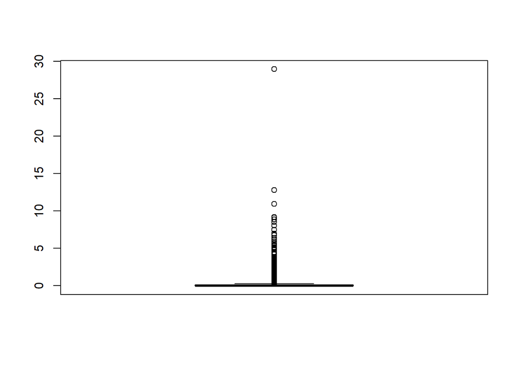

```r
boxplot(videoGamesSales$EU_Sales)
```

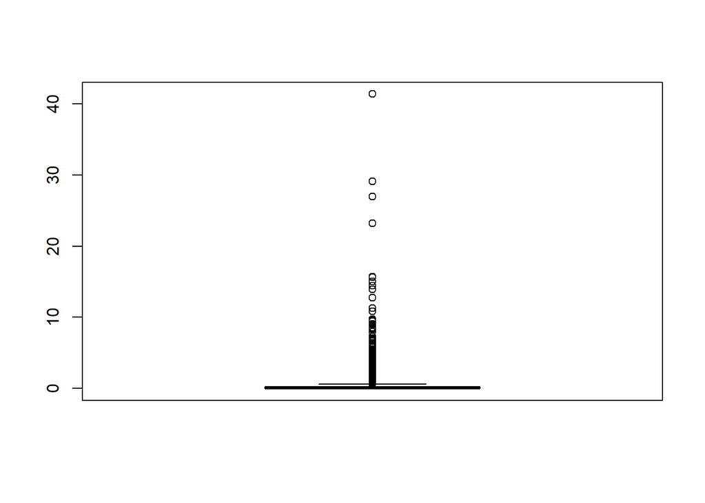

```r
boxplot(videoGamesSales$NA_Sales)
```

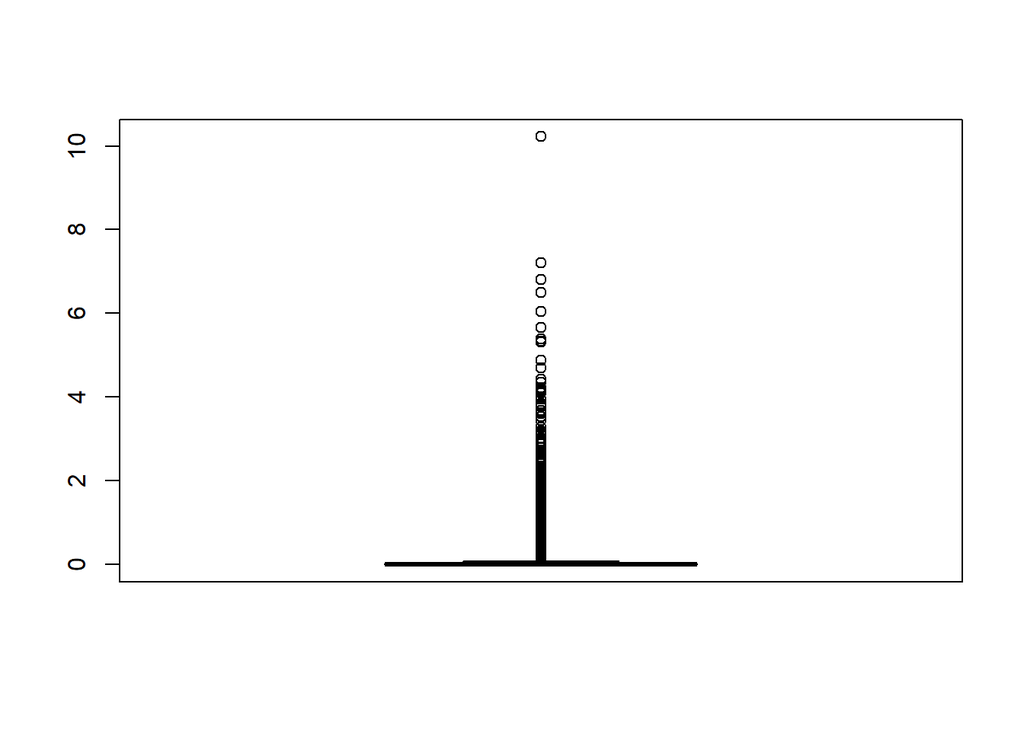

```r
boxplot(videoGamesSales$JP_Sales)
```

### 3. Análisis de los datos.

- A. Selección de los grupos de datos que se quieren analizar/comparar.

```r
allYears <- sort(unique(videoGamesSales$Year_of_Release))
allGenres <- unique(videoGamesSales$Genre)
allPlatforms <- unique(videoGamesSales$Platform)
```

- B. Comprobación de la normalidad y homogeneidad de la varianza. Si es necesario (y posible), aplicar transformaciones que normalicen los datos.

Las puntuaciones de los usuarios como las de metacritic estaran entre 0 y 1.

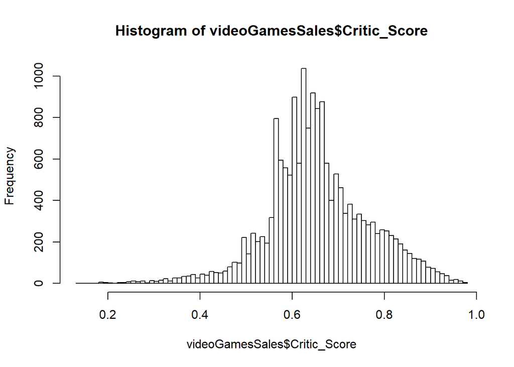

[output not shown]

[output cut: 40 more lines]

```r
videoGamesSales$Critic_Score <- videoGamesSales$Critic_Score / 100
videoGamesSales$User_Score <- videoGamesSales$User_Score / 10

print(hist(videoGamesSales$Critic_Score, breaks = 100))
```

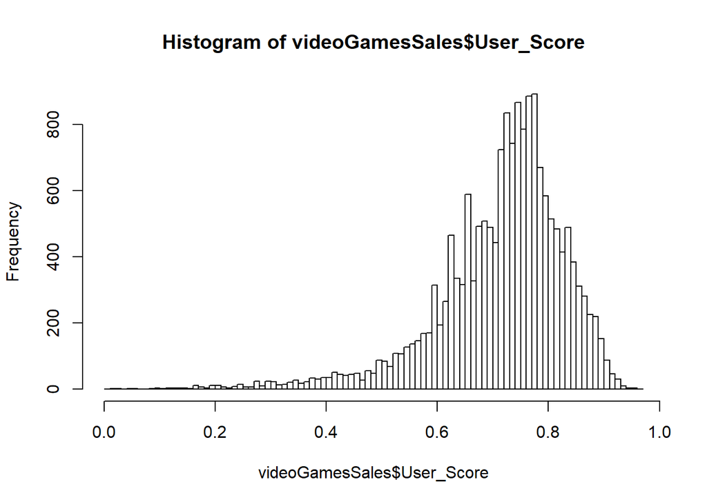

[output not shown]

[output cut: 43 more lines]

```r
print(hist(videoGamesSales$User_Score, breaks = 100))
```

- C. Aplicación de pruebas estadísticas (tantas como sea posible) para comparar los grupos de datos.
  - Vamos a comparar si las puntuaciones de metacritic son idénticas según el género con una significancia del 0.05.

```r
kruskal.test(Critic_Score ~ Genre, data = videoGamesSales)
```

```
##
##  Kruskal-Wallis rank sum test
##
## data:  Critic_Score by Genre
## Kruskal-Wallis chi-squared = 403.24, df = 11, p-value < 2.2e-16
```

Rechazamos la hipótesis nula de que son idénticas ya que el p-valor < 0.05, por lo que podemos decir que son poblaciones no idénticas.

```
- Vamos a comparar si las puntuaciones de los usuarios son idénticas según el género con una significancia del 0.05.
```

```r
kruskal.test(User_Score ~ Genre, data = videoGamesSales)
```

```
##
##  Kruskal-Wallis rank sum test
##
## data:  User_Score by Genre
## Kruskal-Wallis chi-squared = 317.23, df = 11, p-value < 2.2e-16
```

Rechazamos la hipótesis nula de que son idénticas ya que el p-valor < 0.05, por lo que podemos decir que son poblaciones no idénticas.

### 4. Representación de los resultados a partir de tablas y gráficas.

```r
library(ggplot2)
library(scales)

analyzeSales <- function(salesToAnalyze, years, mainTitle, ylabel){
  mm <- matrix(0, nrow = length(allGenres), ncol = length(years))
  colnames(mm) <- as.character(years)
  rownames(mm) <- as.character(allGenres)

  for (gnr in allGenres)
  {
    data <- c()
    for (y in years)
    {
      sales <- subset(salesToAnalyze, videoGamesSales$Genre == gnr & videoGamesSales$Year_of_Release == y)

      if (length(sales > 0)){
        sales <- mean(sales)
      }
      else{
        sales <- 0
      }

      data <- append(data, sales)
    }
    mm[as.character(gnr),] <- data
  }
  {
  barplot(as.matrix(mm), main=mainTitle, ylab = ylabel, xlab = "Years", cex.lab = 0.9, cex.main = 1.4, beside=TRUE, col=topo.colors(length(allGenres)), ylim = c(0.0, round(max(mm),1)))
  legend("topright",  as.character(allGenres), cex=0.6, bty="n", fill=topo.colors(length(allGenres)))
  }
}
```

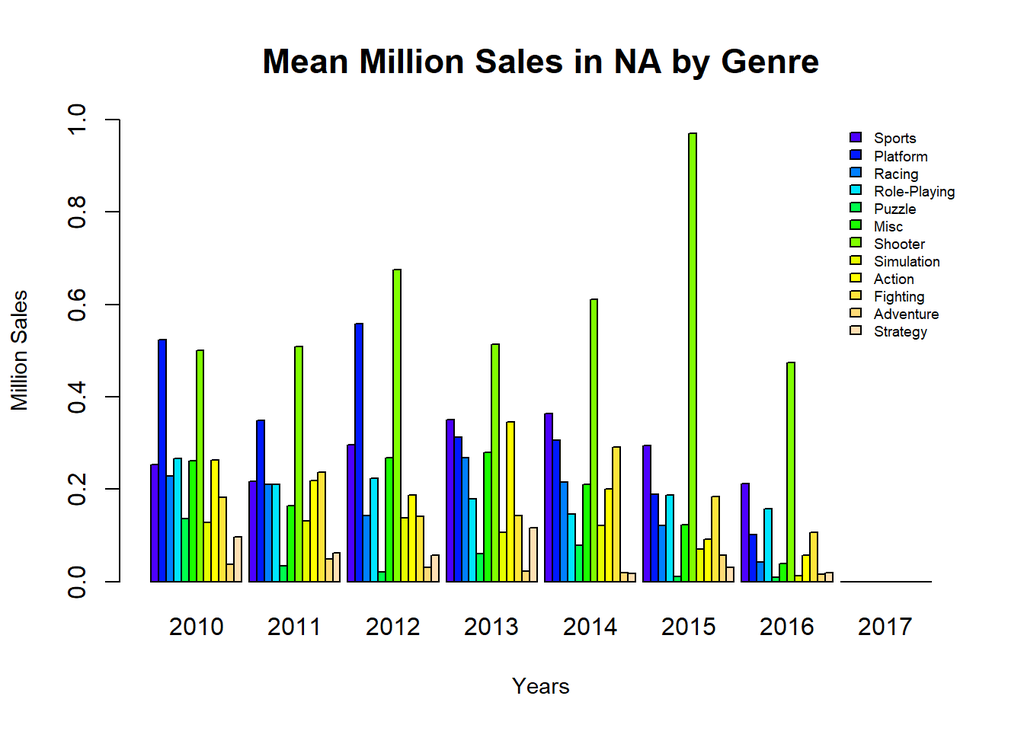

```r
yrs <- allYears[allYears > 2009]

analyzeSales(salesToAnalyze = videoGamesSales$NA_Sales, years = yrs, mainTitle ="Mean Million Sales in NA by Genre", ylabel = "Million Sales")
```

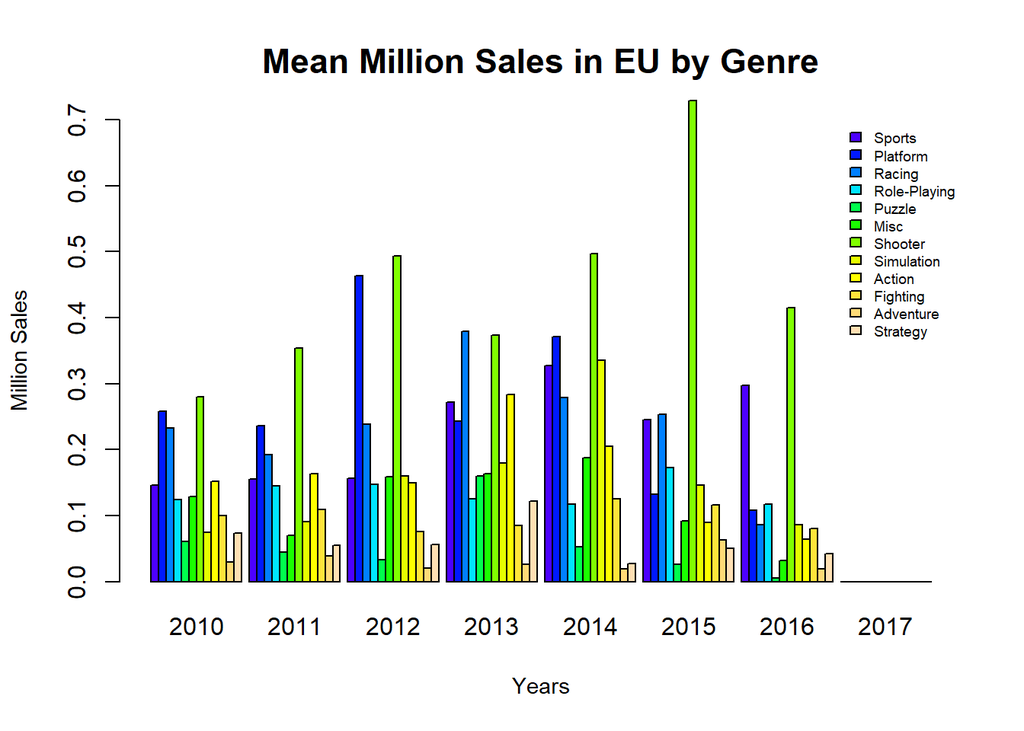

```r
analyzeSales(salesToAnalyze = videoGamesSales$EU_Sales, years = yrs, mainTitle ="Mean Million Sales in EU by Genre", ylabel = "Million Sales")
```

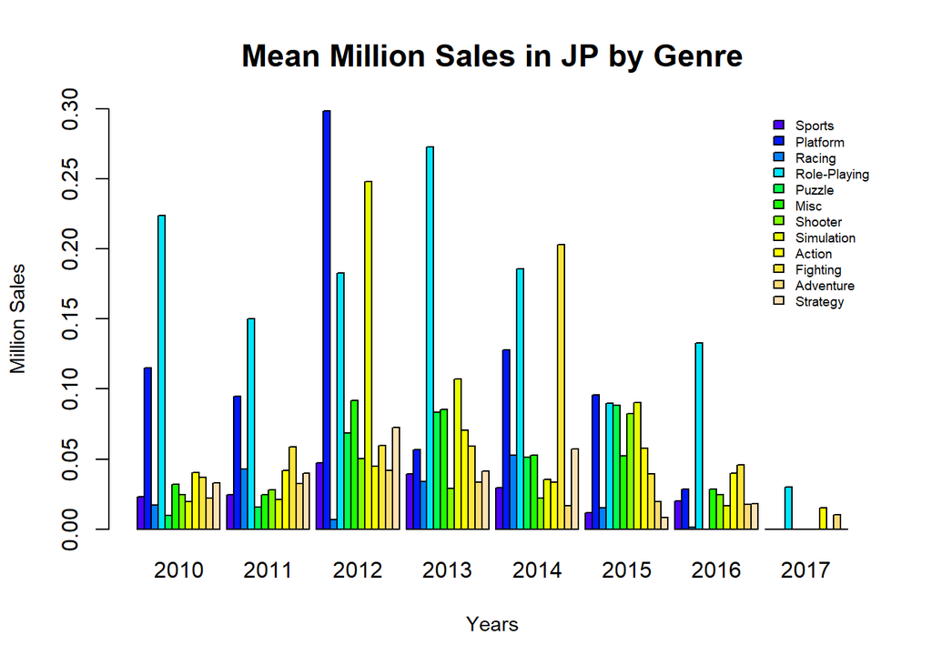

```r
analyzeSales(salesToAnalyze = videoGamesSales$JP_Sales, years = yrs, mainTitle ="Mean Million Sales in JP by Genre", ylabel = "Million Sales")
```

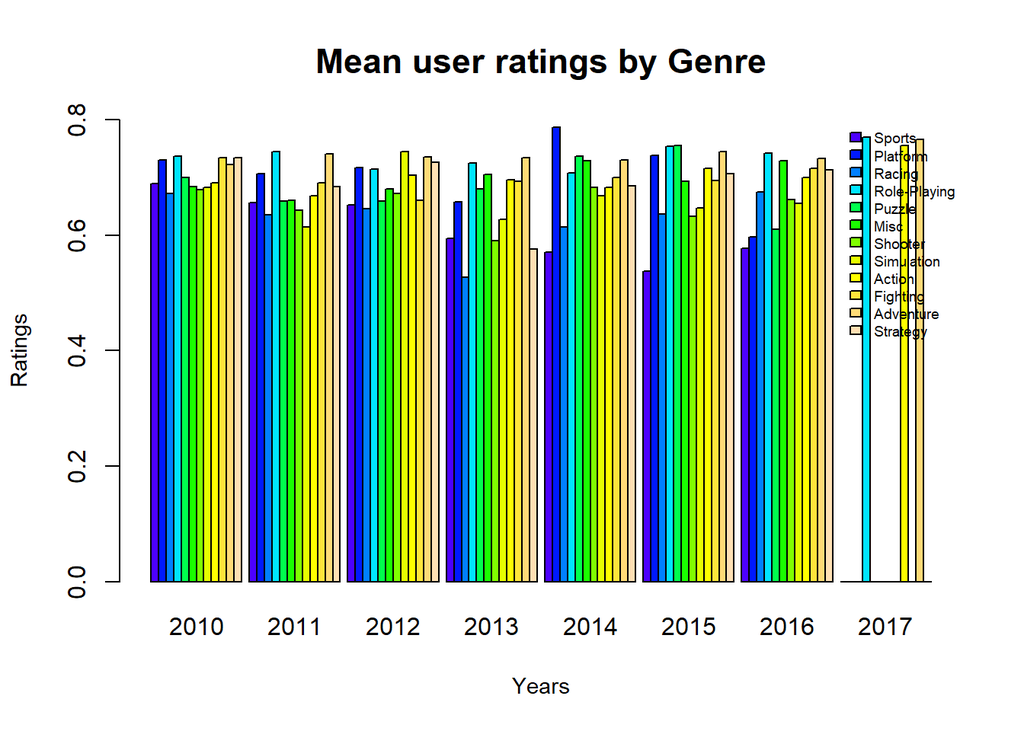

```r
analyzeSales(salesToAnalyze = videoGamesSales$User_Score, years = yrs, mainTitle ="Mean user ratings by Genre", ylabel = "Ratings")
```

[figure not shown]

```r
analyzeSales(salesToAnalyze = videoGamesSales$Critic_Score, years = yrs, mainTitle ="Mean metacritic ratings by Genre", ylabel = "Ratings")
```

### 5. Resolución del problema. A partir de los resultados obtenidos, ¿cuáles son las conclusiones? ¿Los resultados permiten responder al problema?

#### - ¿En qué genero deberían invertir las empresas para garantizar una mayor probabilidad de éxito en Europa?

Como podemos observar en los anteriores gráficos, las ventas en videojuegos varían según la región y el género al que pertenecen. Concretamente podemos ver como el género de Shooter seguido del de Sports fueron incrementando su éxito con los años y se han mantenido en posiciones altas. Sin embargo, en el caso de los juegos de plataformas podemos ver cómo en un inicio estaba en tendencia y tenía un número elevado en ventas, pero a partir del 2014 empezó a decaer notablemente. Por lo tanto, actualmente no sería un buen momento para invertir en dicho género. En lo que concierne a los juegos de Shooter cabe tener en cuenta que durante el año 2013 las ventas no fueron tan notables. Por el contrario, en 2015 se dispararon y en 2016 pese a que no eran tan altas como el año anterior también destacaban en comparación con el resto de géneros. En cuanto al de deporte, como ya se ha mencionado anteriormente, a medida que pasan los años este va incrementando o manteniendo su éxito y ventas. De manera que podemos decir, que las empresas que apuesten ambos géneros tendrán más probabilidad de éxito en ventas. Y finalmente en cuanto al resto de géneros, podemos ver como destacan menos y por lo tanto a su vez tienen menos ganancias.